# Homework_4

**Group H: Carraro, Saveri, Monteiro Milano Oliveira**

```r
library(MASS)
library(DAAG)
library(boot)
library(dplyr)
library(MPV)
library(lattice)
```

# DAAG Exercises

Chapter 6 (from page 214), exercises 6, 8, 10, 11.  
Chapter 8 (from page 281), exercises 1, 2, 3, 6.

## Chapter 6, Exercise 6

**The following investigates the consequences of not using a logarithmic transformation for the `nihills` data analysis. The second differs from the first having a `dist x climb` interaction term, additional to linear terms in `dist` and `climb`.**

1. **Fit the two models:**

```r
nihills.lm <- lm(time ~ dist+climb, data=nihills)
nihills2.lm <- lm(time ~ dist+climb+dist:climb, data = nihills)
anova(nihills.lm, nihills2.lm)
```

2. **Using the $F$-test result, make a tentative choice of model, and proceed to examine diagnostic plots. Are there any problematic observation? What happens if these points are removed? Refit both of the above models, and check the diagnostic again.**

#### Solution

We fit the two models:

```r
nihills.lm <- lm(time ~ dist+climb, data=nihills)
nihills2.lm <- lm(time ~ dist+climb+dist:climb, data = nihills)
anova(nihills.lm, nihills2.lm)
```

```
## Analysis of Variance Table
##
## Model 1: time ~ dist + climb
## Model 2: time ~ dist + climb + dist:climb
##   Res.Df      RSS Df Sum of Sq      F    Pr(>F)
## 1     20 0.189361
## 2     19 0.039361  1      0.15 72.406 6.623e-08 ***
## ---
## Signif. codes:  0 '***' 0.001 '**' 0.01 '*' 0.05 '.' 0.1 ' ' 1
```

The small $p$-value of the F-test result of the `anova` table above suggests us to accept the Model 2 (namely the one including an interaction term, thus rejecting the hypothesis that the interaction term should be null) in place of the Model 1.

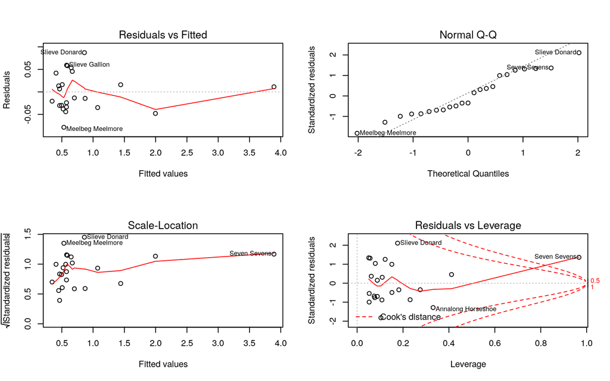

```r
#diagnistics for model 2
par(mfrow=c(2,2), oma=c(0,0,0,0))
plot(nihills2.lm)
```

According to the Residual vs Fitted plot, we can see that `Slieve Donard` and `Meelberg Meelmore` have high residuals. Moreover, looking at the Residual vs Leverage plot we can see that `Seven Sevens` is an outlier (having large Cook’s distance). Hence these observation can be considered problematic, we decided to remove them from the model and refit it.

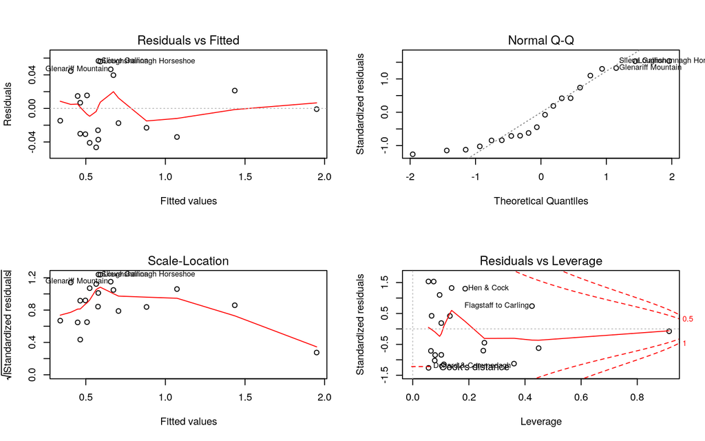

```r
#remove problematic observations
remove<-c("Slieve Donard", "Meelbeg Meelmore", "Seven Sevens")
nihills.without <- nihills %>% subset(!rownames(nihills) %in% remove)
#refit both models
nihills.lm <- lm(time ~ dist+climb, data=nihills.without)
nihills2.lm <- lm(time ~ dist+climb+dist:climb, data = nihills.without)
#check diagnostic plots
par(mfrow=c(2,2), oma=c(0,0,0,0))
#model 2
plot(nihills2.lm)
```

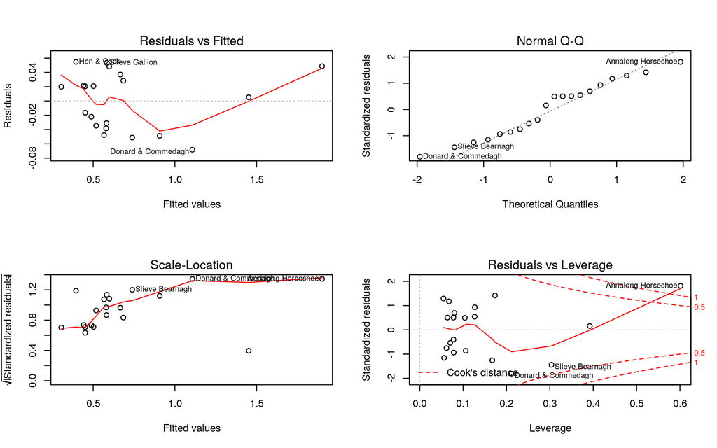

```r
#model 1
plot(nihills.lm)
```

Checking the diagnostics plots after removing the points that we considered problematic, we can see that `Annalong Horsehoe` is an outlier for Model 1, while there are no more particularly problematic points for Model 2.

```r
#check anova again
anova(nihills.lm, nihills2.lm)
```

```
## Analysis of Variance Table
##
## Model 1: time ~ dist + climb
## Model 2: time ~ dist + climb + dist:climb
##   Res.Df      RSS Df Sum of Sq      F  Pr(>F)
## 1     17 0.030854
## 2     16 0.022977  1 0.0078776 5.4856 0.03244 *
## ---
## Signif. codes:  0 '***' 0.001 '**' 0.01 '*' 0.05 '.' 0.1 ' ' 1
```

The $p$-value has significantly increased. We can remove the point `Annalong Horseshoe`, which is problematic for the first model, and refit both models.

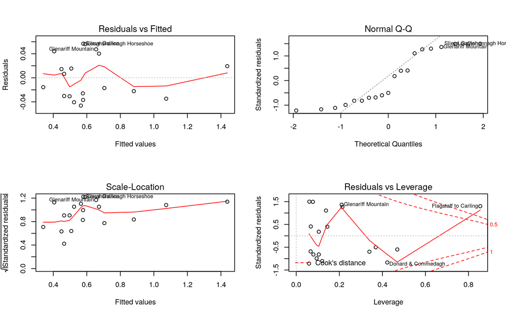

```r
nihills.without.annalong <- nihills.without %>% subset(rownames(nihills.without)
                                                       != "Annalong Horseshoe")
#refit both models
nihills.lm <- lm(time ~ dist+climb, data=nihills.without.annalong)
nihills2.lm <- lm(time ~ dist+climb+dist:climb, data = nihills.without.annalong)
par(mfrow=c(2,2), oma=c(0,0,0,0))
#model 2
plot(nihills2.lm)
```

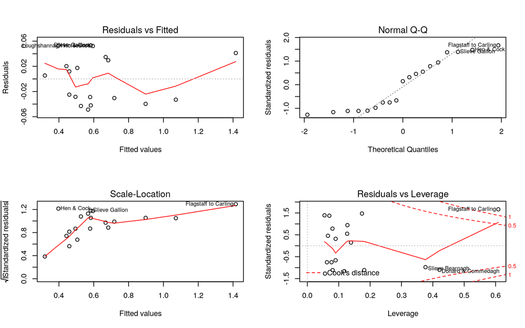

```r
#model 1
plot(nihills.lm)
```

The point `Flagstaff to Carling` has now high Cook distance for both models, so we decided to remove this point too.

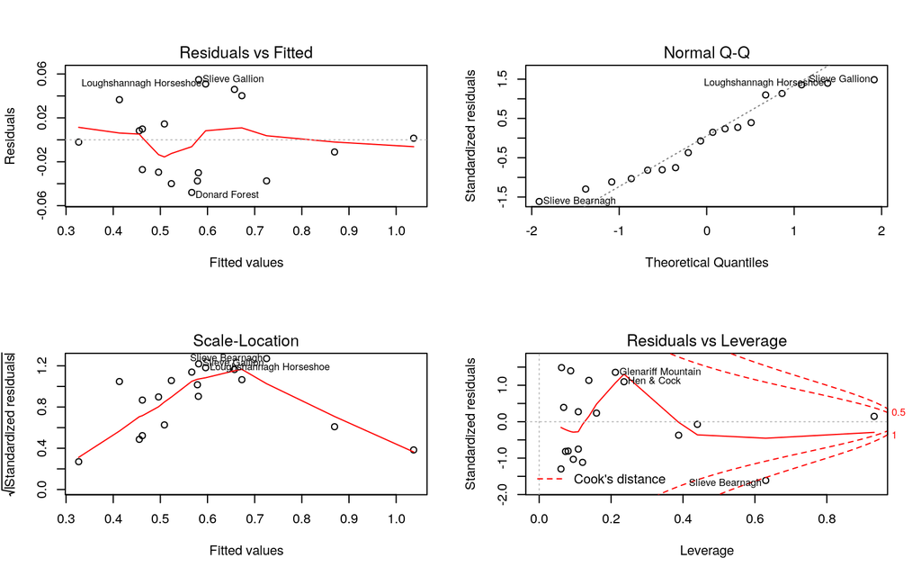

```r
nihills.without.flagstaff <- nihills.without.annalong %>% subset(rownames(nihills.without.annalong)
                                                                 != "Flagstaff to Carling")
nihills.lm <- lm(time ~ dist + climb, data=nihills.without.flagstaff)
nihills2.lm <- lm(time ~ dist + climb + dist:climb, data = nihills.without.flagstaff)
par(mfrow=c(2,2), oma=c(0,0,0,0))
#model 2
plot(nihills2.lm)
```

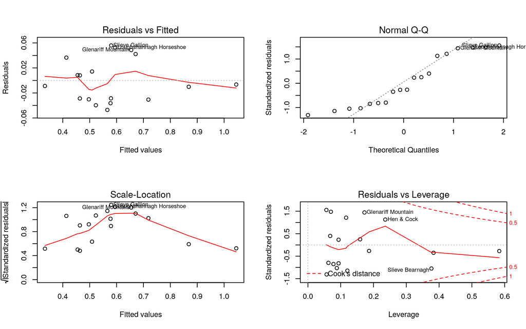

```r
#model 1
plot(nihills.lm)
```

We can see that we removed all problematic points. We check the `anova` test again:

```r
anova(nihills.lm, nihills2.lm)
```

```
## Analysis of Variance Table
##
## Model 1: time ~ dist + climb
## Model 2: time ~ dist + climb + dist:climb
##   Res.Df      RSS Df  Sum of Sq      F Pr(>F)
## 1     15 0.020572
## 2     14 0.020389  1 0.00018262 0.1254 0.7285
```

The $p$-value is again increased significantly, and the `anova` test now suggests that there is no significant improvement in choosing the more complex Model 2 instead of the simpler Model 1.

## Chapter 6, Exercise 8

**Apply the `lm.ridge()` function to the `litters` data, using generalized cross-validation (GCV) criterion to choose the tuning parameter. (GCV is an approximation to cross-validation.)**

1. **In particular, estimate the coefficients of the model relating `brainwt` to `bodywt` and `lsize` and compare with the results obtained using `lm()`.**
2. **Using both ridge and ordinary regression, estimate the mean brain weight when litter size is $10$ and body weight is $7$. Use the bootstrap, with case-resampling, to compute approximate $95\%$ percentile confidence intervals using each method. Compare with the interval obtained using `predict.lm()`.**

#### Solution

```r
MASS::select(lm.ridge(brainwt ~ bodywt + lsize, data=litters, lambda=seq(0, 0.1, 0.01)))
```

```
## modified HKB estimator is 0
## modified L-W estimator is 0
## smallest value of GCV  at 0.1
```

```r
#GCV suggests optimal lambda to be 0.1
litters.lm.ridge <- lm.ridge(brainwt ~ bodywt + lsize, data=litters, lambda=0.1)
#lm.ridge coefficients
litters.lm.ridge
```

```
##                bodywt      lsize
## 0.19998145 0.02236033 0.00580276
```

```r
litters.lm <- lm(brainwt ~ bodywt + lsize, data=litters)$coefficients
litters.lm
```

```
## (Intercept)      bodywt       lsize
## 0.178246962 0.024306344 0.006690331
```

Comparing the coefficients of the two models, we can see that both the coefficients of `bodywt` and `lsize` in the ridge model are penalized in favor of the intercept coefficient.

```r
#estimation for the ridge regression model
paste("Ridge estimate: ", as.vector(coef(litters.lm.ridge))%*%c(1,7,10))
```

```
## [1] "Ridge estimate:  0.414531372401127"
```

```r
#estimation for the lm model
paste("lm estimate: ", as.vector(litters.lm%*%c(1,7,10)))
```

```
## [1] "lm estimate:  0.415294682299934"
```

```r
#boostrap c.i. for ordinary lm
lm.boot.stat<-function(data, formula, i) {
  d <- data[i,] #select the sample
  litters.lm <-summary(lm(formula, data=d))$coefficients[,1] #coeff estimate from the model
  return(as.vector(litters.lm%*%c(1,7,10)))
}

boot.lm<-boot(data=litters, statistic=lm.boot.stat, formula=brainwt~bodywt+lsize, R=1000)
boot.ci(boot.lm, type="perc")
```

```
## BOOTSTRAP CONFIDENCE INTERVAL CALCULATIONS
## Based on 1000 bootstrap replicates
##
## CALL :
## boot.ci(boot.out = boot.lm, type = "perc")
##
## Intervals :
## Level     Percentile
## 95%   ( 0.4052,  0.4236 )
## Calculations and Intervals on Original Scale
```

```r
#bootstrap c.i. for ridge lm
ridge.boot.stat<-function(data, formula, i) {
  d<-data[i,] #select the sample
  litters.ridge<-as.vector(coef(lm.ridge(formula, data=d, lambda=0.1)))
  return(litters.ridge%*%c(1,7,10))
}

boot.ridge<-boot(data=litters, statistic=ridge.boot.stat, formula=brainwt~bodywt+lsize, R=1000)
boot.ci(boot.ridge, type="perc")
```

```
## BOOTSTRAP CONFIDENCE INTERVAL CALCULATIONS
## Based on 1000 bootstrap replicates
##
## CALL :
## boot.ci(boot.out = boot.ridge, type = "perc")
##
## Intervals :
## Level     Percentile
## 95%   ( 0.4052,  0.4220 )
## Calculations and Intervals on Original Scale
```

```r
#interval obtained using predict.lm
new.data<-data.frame(bodywt=7, lsize=10)
predict.lm(lm(brainwt~bodywt+lsize, data=litters), new.data, interval="confidence")
```

```
##         fit       lwr       upr
## 1 0.4152947 0.4062582 0.4243312
```

We can observe that bootstrap-based confidence intervals and `predict.lm()` confidence interval are similar.

## Chapter 6, Exercise 10

**The data frame `table.b3` in the *MPV* package contains data on gas mileage and $11$ other variables for a sample of $32$ automobiles.**

1. **Construct a scatterplot of `y` (mpg) versus `x1` (displacement). Is the relationship between these variables non-linear?**
2. **Use the `xyplot()` function, and `x11` (type of transmission) as a `group` variable. Is a linear model reasonable for these data?**
3. **Fit the model relating `y` to `x1` and `x11` which gives two lines having possibly different slopes and intercepts. Check the diagnostics. Are there any influential observations? Are there any influential outliers?**
4. **Plot the residuals against the variable `x7` (number of transmission speeds), again using `x11` as a `group` variable. Is there anything striking about this plot?**

#### Solution

1. The scatterplot is

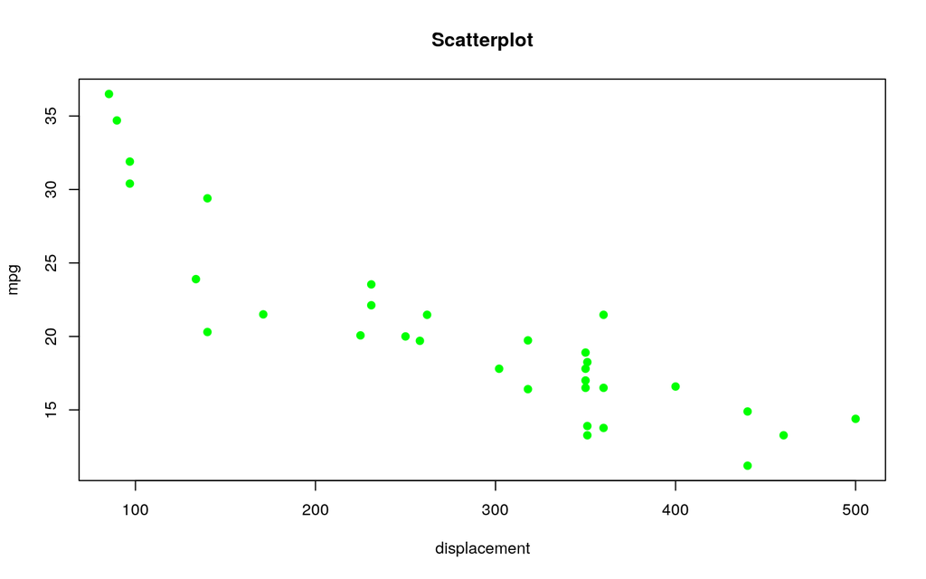

```r
gas_mil <- table.b3
attach(gas_mil)
plot(x1, y, pch=20, col="green", cex=1.5, xlab="displacement", ylab="mpg", main="Scatterplot")
```

The relationship line between these two variables seems sligthly curved, but a simple linear regression with a negative correlation coefficient could do.

2. The plot is

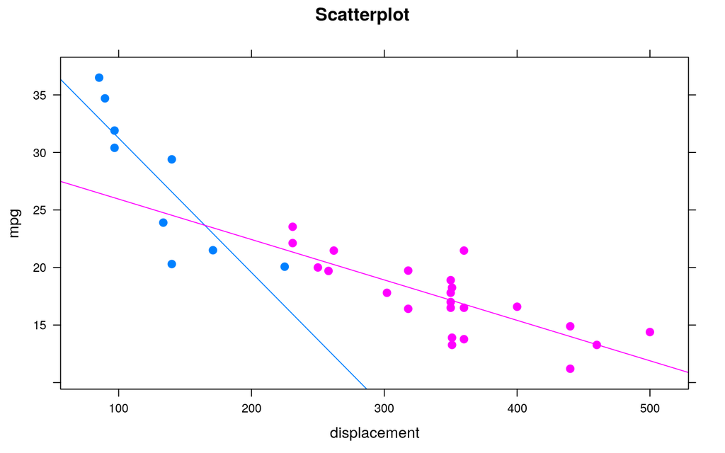

```r
xyplot(y~x1, groups=x11, data=gas_mil, type = c("p", "r"), pch=20, cex=1.5, xlab="displacement",
       ylab="mpg", main="Scatterplot")
```

Taking into consideration the variable x11 as a group variable, a linear model might not be the most appropriate model for this data because this variable separates the data into two distinct groups. Each group covers a different range of the variable x1. Therefore, this might be influencing the model and making it non-linear.

3. The fitted model is

```r
fit1 <- lm(y~x1+x11, data=gas_mil)
summary(fit1)
```

```
##
## Call:
## lm(formula = y ~ x1 + x11, data = gas_mil)
##
## Residuals:
##     Min      1Q  Median      3Q     Max
## -6.9153 -1.8882  0.1106  1.7706  6.7829
##
## Coefficients:
##              Estimate Std. Error t value Pr(>|t|)
## (Intercept) 33.618408   1.539505  21.837  < 2e-16 ***
## x1          -0.045736   0.008682  -5.268  1.2e-05 ***
## x11         -0.498689   2.228198  -0.224    0.824
## ---
## Signif. codes:  0 '***' 0.001 '**' 0.01 '*' 0.05 '.' 0.1 ' ' 1
##
## Residual standard error: 3.115 on 29 degrees of freedom
## Multiple R-squared:  0.7727, Adjusted R-squared:  0.757
## F-statistic: 49.28 on 2 and 29 DF,  p-value: 4.696e-10
```

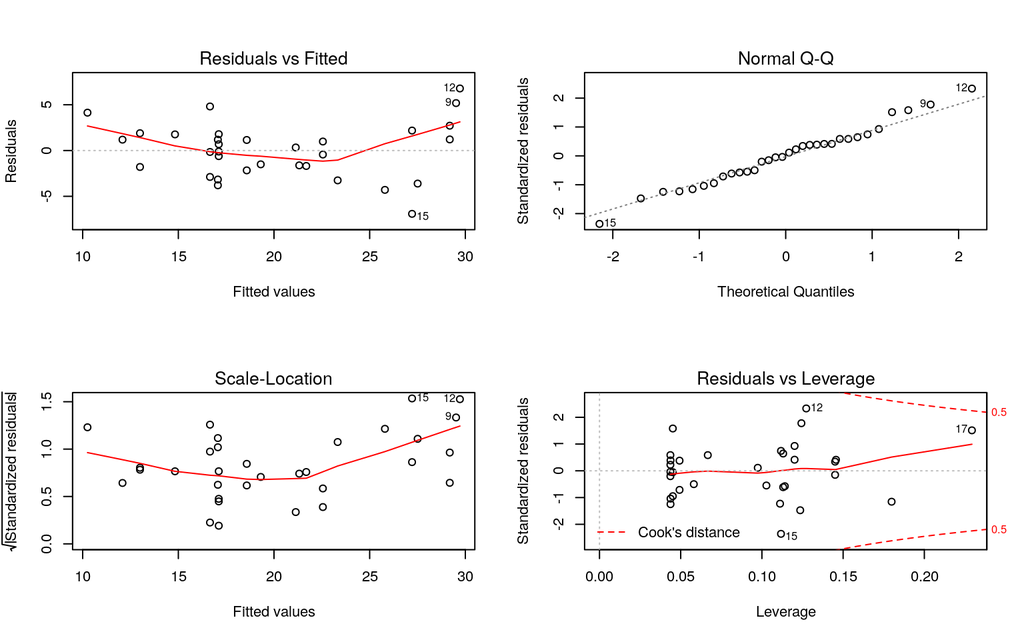

```r
par(mfrow=c(2,2))
plot(fit1)
```

There is an influential observation. It is the observation number $17$. In the plot Residuals vs Leverage, it can be seen that this point highly influences the regression line. If this point is removed, the coefficients will most probably change. On the other hand, there isn’t any influential outlier because no observation lies outside the dashed lines of this plot.

4. The plot of the residuals is

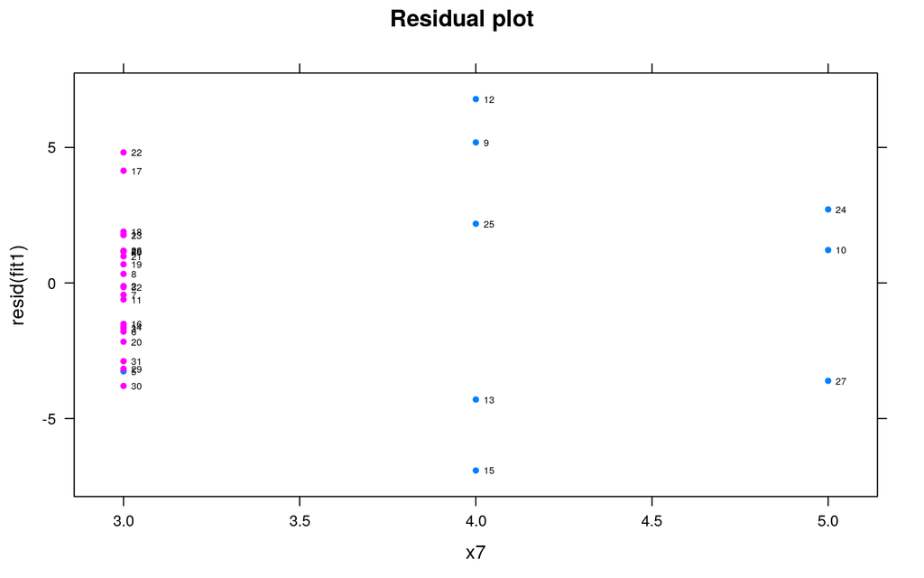

```r
xyplot(resid(fit1) ~ x7, group=x11, data=gas_mil, pch=20, main="Residual plot",
       panel=function(x, y, ...) {
         panel.xyplot(x, y, ...);
         ltext(x=x, y=y, labels=seq(1, length(x7), 1), pos=4, offset=0.8, cex=0.5)
       })
```

In this plot we observe that the points are all well calssified and almost perfectly separated except for one blue point which is in the middle of the pink ones.

## Chapter 6, Exercise 11

**The following code is designed to explore effects that can result from the omission of explanatory variables:**

```r
> x1 <- runif(10)                       # predictor which will be missing
> x2 <- rbinom(10, 1, 1-x1)             # observed predictor which depends
>                                       # on missing predictor
> y <- 5*x1 + x2 + rnorm(10, sd=.1)     # simulated model; coef
>                                       # of x2 is positive
> y.lm <- lm(y ~ factor(x2))            # model fitted to observed data
> coef(y.lm)
(Intercept) factor(x2)1
 2.8224119 -0.6808925                   # effect of missing variable:
                                        # coefficient of x2 has wrong sign
> y.lm2 <- lm(y ~ x1 + factor(x2))      # correct model
> coef(y.lm2)
(Intercept)        x1  factor(x2)1
0.06654892 4.91216206  0.92489061       # coef estimates are now OK
```

What happens if `x2` is generated according to `x2 <- rbinom(10, 1, x1)`? `x2 <- rbinom(10, 1, .5)`?

#### Solution

The model of the example is:

```r
x1 <- runif(10)                       # predictor which will be missing
x2 <- rbinom(10, 1, 1-x1)             # observed predictor which depends
y <- 5*x1 + x2 + rnorm(10, sd=.1)     # simulated model; coef of x2 is positive
y.lm <- lm(y ~ factor(x2))            # model fitted to observed data
coef(y.lm)
```

```
## (Intercept) factor(x2)1
##    4.284348   -2.075365
```

We can see the effect of missing variable: sometimes the coefficient of `x2` has wrong sign.

```r
y.lm2 <- lm(y ~ x1 + factor(x2))      # correct model
coef(y.lm2)
```

```
## (Intercept)          x1 factor(x2)1
##  -0.1272628   5.1336982   1.0383036
```

The coefficients estimates are now OK.

If `x2` is generated according to `x2 <- rbinom(10, 1, x1)`, so if it is a Binomial with a probability equal to $x1$ (that is the complementary of the previous probability of `x2`) we have that

```r
x2 <- rbinom(10, 1, x1)
y2 <- 5*x1 + x2 + rnorm(10, sd=.1)
y2.lm <- lm(y ~ factor(x2))
coef(y2.lm)
```

```
## (Intercept) factor(x2)1
##    2.079156    2.508123
```

Now the coefficient of `x2` has no more wrong sign, and but sometimes it is instead quite different from the real coefficient $1$.

```r
y2.lm2 <- lm(y ~ x1 + factor(x2))
coef(y2.lm2)
```

```
## (Intercept)          x1 factor(x2)1
##   1.2157873   3.3642795   0.5102498
```

We can see that instead with the addition of the variable `x1`, as the model wuold require, sometimes the coeeficent of `x2` has wrong sign.

Instead if `x2` is generated according to `x2 <- rbinom(10, 1, .5)`, so with a probability equal to $0.5$, we have that

```r
x2 <- rbinom(10, 1, .5)
y3 <- 5*x1 + x2 + rnorm(10, sd=.1)
y3.lm <- lm(y ~ factor(x2))
coef(y3.lm)
```

```
## (Intercept) factor(x2)1
##  2.87736874 -0.09155226
```

```r
y3.lm2 <- lm(y ~ x1 + factor(x2))
coef(y3.lm2)
```

```
## (Intercept)          x1 factor(x2)1
##   1.0217077   3.9649087   0.1720227
```

So we can see that now the variable `x2` can have negative sign in both the two models. Beside, now sometimes the estimate of the coefficient of `x1` is not so accurate.

## Chapter 8, Exercise 1

**The following table shows numbers of occasions when inhibition (i.e., no flow of current across a membrane) occurred within 120 s, for different concentrations of the protein peptide-C (data are used with the permission of Claudia Haarmann, who obtained these data in the course of her PhD research). The outcome `yes` implies that inhibition has occurred.**

| conc | 0.1 | 0.5 | 1 | 10 | 20 | 30 | 50 | 70 | 80 | 100 | 150 |
| --- | --- | --- | --- | --- | --- | --- | --- | --- | --- | --- | --- |
| no | 7 | 1 | 10 | 9 | 2 | 9 | 13 | 1 | 1 | 4 | 3 |
| yes | 0 | 0 | 3 | 4 | 0 | 6 | 7 | 0 | 0 | 1 | 7 |

**Use logistic regression to model the probability of inhibition as a function of protein concentration.**

#### Solution

```r
conc. <- c(0.1, 0.5, 1, 10, 20, 30, 50, 70, 80, 100, 150)
no <- c(7, 1, 10, 9, 2, 9, 13, 1, 1, 4, 3)
yes <- c(0, 0, 3, 4, 0, 6, 7, 0, 0, 1, 7)
margin <- no+yes
prop <- yes/margin
table1 <- data.frame(conc.,no,yes,margin,prop)
table1
```

```
##    conc. no yes margin      prop
## 1    0.1  7   0      7 0.0000000
## 2    0.5  1   0      1 0.0000000
## 3    1.0 10   3     13 0.2307692
## 4   10.0  9   4     13 0.3076923
## 5   20.0  2   0      2 0.0000000
## 6   30.0  9   6     15 0.4000000
## 7   50.0 13   7     20 0.3500000
## 8   70.0  1   0      1 0.0000000
## 9   80.0  1   0      1 0.0000000
## 10 100.0  4   1      5 0.2000000
## 11 150.0  3   7     10 0.7000000
```

```r
conc.logit <- glm(prop ~ conc., family=binomial(link="logit"), weights=margin, data=table1)
summary(conc.logit)
```

```
##
## Call:
## glm(formula = prop ~ conc., family = binomial(link = "logit"),
##     data = table1, weights = margin)
##
## Deviance Residuals:
##     Min       1Q   Median       3Q      Max
## -1.8159  -1.0552  -0.6878   0.3667   1.0315
##
## Coefficients:
##             Estimate Std. Error z value Pr(>|z|)
## (Intercept) -1.32701    0.33837  -3.922 8.79e-05 ***
## conc.        0.01215    0.00496   2.450   0.0143 *
## ---
## Signif. codes:  0 '***' 0.001 '**' 0.01 '*' 0.05 '.' 0.1 ' ' 1
##
## (Dispersion parameter for binomial family taken to be 1)
##
##     Null deviance: 16.683  on 10  degrees of freedom
## Residual deviance: 10.389  on  9  degrees of freedom
## AIC: 30.988
##
## Number of Fisher Scoring iterations: 4
```

The results suggests that `conc` is a reasonable explanatory variable for the occurrence of inhibition in a time lapse of $120 s$.

## Chapter 8, Exercise 2

**In the data set (an artificial one of $3121$ patients, that is similar to a subset of the data analyzed in Stiell et al., 2001) `minor.head.injury`, obtain a logistic regression model relating `clinically.important.brain.injury` to other variables. Patients whose risk is sufficiently high will be sent for CT (computed tomography). Using a risk threshold of $0.025$ ($2.5\%$), turn the result into a decision rule for use of CT.**

#### Solution

```r
#Dividing the data into train and test data
library(caTools)
set.seed(123)
sample <- sample.split(head.injury, SplitRatio = 0.75)
train <- subset(head.injury, sample==TRUE)
test <- subset(head.injury, sample==FALSE)

#fitting the logistic regression model
fit.glm <- glm(clinically.important.brain.injury ~ ., family=binomial(link="logit"), data=train)
summary(fit.glm)
```

```
##
## Call:
## glm(formula = clinically.important.brain.injury ~ ., family = binomial(link = "logit"),
##     data = train)
##
## Deviance Residuals:
##     Min       1Q   Median       3Q      Max
## -2.2122  -0.3003  -0.1917  -0.1410   3.0383
##
## Coefficients:
##                       Estimate Std. Error z value Pr(>|z|)
## (Intercept)            -4.6055     0.1978 -23.283  < 2e-16 ***
## age.65                  1.3980     0.2206   6.337 2.34e-10 ***
## amnesia.before          0.6181     0.2060   3.001  0.00269 **
## basal.skull.fracture    1.9485     0.2421   8.047 8.49e-16 ***
## GCS.decrease           -0.3086     0.4264  -0.724  0.46918
## GCS.13                  1.2253     0.3232   3.791  0.00015 ***
## GCS.15.2hours           1.9191     0.2019   9.503  < 2e-16 ***
## high.risk               1.1992     0.1895   6.327 2.50e-10 ***
## loss.of.consciousness   0.9110     0.2392   3.809  0.00014 ***
## open.skull.fracture     0.3280     0.3660   0.896  0.37016
## vomiting                1.5073     0.2274   6.629 3.39e-11 ***
## ---
## Signif. codes:  0 '***' 0.001 '**' 0.01 '*' 0.05 '.' 0.1 ' ' 1
##
## (Dispersion parameter for binomial family taken to be 1)
##
##     Null deviance: 1248.0  on 2269  degrees of freedom
## Residual deviance:  839.6  on 2259  degrees of freedom
## AIC: 861.6
##
## Number of Fisher Scoring iterations: 6
```

```r
#predicting
glm.probs <- predict(fit.glm, newdata=test, type="response")
glm.probs[1:24]
```

```
##           5           8          11          16          19          22
## 0.063777301 0.009897334 0.009897334 0.009897334 0.018208875 0.018208875
##          27          30          33          38          41          44
## 0.044089020 0.024256202 0.032919082 0.009897334 0.043180275 0.009897334
##          49          52          55          60          63          66
## 0.009897334 0.009897334 0.086394327 0.009897334 0.018208875 0.018208875
##          71          74          77          82          85          88
## 0.009897334 0.032096851 0.038881416 0.069816747 0.018208875 0.009897334
```

```r
#setting the threshold, where "1" means "use of CT"
glm.predict <- ifelse(glm.probs>0.025, 1, 0)
glm.predict[1:24]
```

```
##  5  8 11 16 19 22 27 30 33 38 41 44 49 52 55 60 63 66 71 74 77 82 85 88
##  1  0  0  0  0  0  1  0  1  0  1  0  0  0  1  0  0  0  0  1  1  1  0  0
```

```r
#calculating the confusion matrix
real <- test$clinically.important.brain.injury
conf_mat1 <- table(glm.predict,real)
conf_mat1
```

```
##            real
## glm.predict   0   1
##           0 423   6
##           1 356  66
```

```r
#calculating the accuracy
print(paste("The accuracy is:", mean(glm.predict==real)))
```

```
## [1] "The accuracy is: 0.574618096357227"
```

A logistic regression model was built with a threshold of $0.025$ and the accuracy of the test was calculated. If the predicted probability is greater than $0.025$ the result of the test is $1$, which means that the patient will be sent to CT.

## Chapter 8, Exercise 3

**Consider again the `moths` data set of Section 8.4.**

1. **What happens to the standard error estimates when the `poisson` family is used in `glm()` instead of the `quasipoisson` family?**
2. **Analyze the $P$ moths, in the same way as the $A$ moths were analyzed. Comment on the effect of transect length.**

#### Solution

The code to generate the figure is taken from DAAG book, page 261 (with a correction seen in the [file](https://maths-people.anu.edu.au/~johnm/r-book/3edn/updates/updates2013-2018-bklt.pdf) at this [page](https://maths-people.anu.edu.au/~johnm/r-book/daagur3.html))).

```r
library(lattice)

## Number of moths by habitat
rbind(Number=table(moths[, 4]), sapply(split(moths[, -4], moths$habitat), apply, 2, sum));
```

```
##        Bank Disturbed Lowerside NEsoak NWsoak SEsoak SWsoak Upperside
## Number    1         7         9      6      3      7      3         5
## meters   21        49       191    254     65    193    116       952
## A         0         8        41     14     71     37     20        28
## P         4        33        17     14     19      6     48         8
```

Here, Number is the number of transects for that habitat, while meters is the total length.

[figure not shown]

```r
dotplot(habitat ~ A, data=moths, xlab="Number of moths (species A)", panel=function(x, y, ...){
    panel.dotplot(x,y, pch=1, col="black", ...)
    av <- sapply(split(x,y),mean)
    ypos <- unique(y)
    lpoints(ypos~av, pch=3, cex=1.25, col="black")
  }, key=list(text=list(c("Individual transects", "Mean")),
  points=list(pch=c(1,3), cex=c(1,1.25), col=c("black","gray45")), columns=2))
```

The model will take the form
$$y = \text{habitat effect} + \beta \log(\text{length of section})$$
where $y = \log(\text{expected number of moths})$.

No moths of the first species `A` were found in the `Bank` habitat. This zero count creates problems for the calculation of standard errors. The difficulty can be avoided, for habitats other than `Bank`, by taking `Lowerside` as the reference.

```r
moths$habitat <- relevel(moths$habitat, ref="Lowerside")
```

1. We first use the `quasipoisson` family:

```r
summary(A1.glm <- glm(A ~ habitat + log(meters), family=quasipoisson, data=moths))
```

```
##
## Call:
## glm(formula = A ~ habitat + log(meters), family = quasipoisson,
##     data = moths)
##
## Deviance Residuals:
##     Min       1Q   Median       3Q      Max
## -3.5562  -1.4635  -0.0007   0.9248   3.0822
##
## Coefficients:
##                    Estimate Std. Error t value Pr(>|t|)
## (Intercept)         1.20981    0.45530   2.657   0.0122 *
## habitatBank       -16.90566 2096.58841  -0.008   0.9936
## habitatDisturbed   -1.28323    0.64737  -1.982   0.0561 .
## habitatNEsoak      -0.82170    0.53700  -1.530   0.1358
## habitatNWsoak       1.56243    0.33426   4.674 5.11e-05 ***
## habitatSEsoak       0.06206    0.38515   0.161   0.8730
## habitatSWsoak       0.23143    0.47807   0.484   0.6316
## habitatUpperside   -0.16234    0.58429  -0.278   0.7829
## log(meters)         0.12917    0.15278   0.845   0.4041
## ---
## Signif. codes:  0 '***' 0.001 '**' 0.01 '*' 0.05 '.' 0.1 ' ' 1
##
## (Dispersion parameter for quasipoisson family taken to be 2.700801)
##
##     Null deviance: 257.108  on 40  degrees of freedom
## Residual deviance:  93.991  on 32  degrees of freedom
## AIC: NA
##
## Number of Fisher Scoring iterations: 13
```

Then instead we use the `poisson` family in `glm()`:

```r
summary(A2.glm <- glm(A ~ habitat + log(meters), family=poisson, data=moths))
```

```
##
## Call:
## glm(formula = A ~ habitat + log(meters), family = poisson, data = moths)
##
## Deviance Residuals:
##     Min       1Q   Median       3Q      Max
## -3.5562  -1.4635  -0.0007   0.9248   3.0822
##
## Coefficients:
##                    Estimate Std. Error z value Pr(>|z|)
## (Intercept)         1.20981    0.27705   4.367 1.26e-05 ***
## habitatBank       -16.90566 1275.75387  -0.013  0.98943
## habitatDisturbed   -1.28323    0.39392  -3.258  0.00112 **
## habitatNEsoak      -0.82170    0.32676  -2.515  0.01191 *
## habitatNWsoak       1.56243    0.20340   7.682 1.57e-14 ***
## habitatSEsoak       0.06206    0.23436   0.265  0.79114
## habitatSWsoak       0.23143    0.29090   0.796  0.42628
## habitatUpperside   -0.16234    0.35554  -0.457  0.64796
## log(meters)         0.12917    0.09297   1.389  0.16471
## ---
## Signif. codes:  0 '***' 0.001 '**' 0.01 '*' 0.05 '.' 0.1 ' ' 1
##
## (Dispersion parameter for poisson family taken to be 1)
##
##     Null deviance: 257.108  on 40  degrees of freedom
## Residual deviance:  93.991  on 32  degrees of freedom
## AIC: 226.71
##
## Number of Fisher Scoring iterations: 13
```

The use of a quasi-Poisson model, rather than a Poisson model, has increased standard errors by a factor of $\sqrt{2.7} = 1.64$, where $2.7$ is the dispersion parameter. So the standard error estimates when the `poisson` family is used in `glm()` instead of the `quasipoisson` family are reduced by a factor of $1/\sqrt{2.7} = 0,61$. Besides, with the Poisson model more coefficents are become statistically significant.

2. We now analyze the $P$ moths, in the same way as the $A$ moths were analyzed. We first use the `quasipoisson` family:

```r
summary(P1.glm <- glm(P ~ habitat + log(meters), family=quasipoisson, data=moths))
```

```
##
## Call:
## glm(formula = P ~ habitat + log(meters), family = quasipoisson,
##     data = moths)
##
## Deviance Residuals:
##     Min       1Q   Median       3Q      Max
## -2.9479  -1.3155  -0.4167   0.5660   2.9719
##
## Coefficients:
##                  Estimate Std. Error t value Pr(>|t|)
## (Intercept)       -0.8608     0.6745  -1.276  0.21105
## habitatBank        0.5569     0.8837   0.630  0.53301
## habitatDisturbed   1.4364     0.5172   2.777  0.00909 **
## habitatNEsoak     -0.3211     0.5844  -0.549  0.58651
## habitatNWsoak      1.0106     0.5309   1.904  0.06598 .
## habitatSEsoak     -1.0697     0.7560  -1.415  0.16673
## habitatSWsoak      1.6383     0.4582   3.575  0.00113 **
## habitatUpperside  -1.5773     0.7757  -2.033  0.05038 .
## log(meters)        0.5552     0.1759   3.157  0.00347 **
## ---
## Signif. codes:  0 '***' 0.001 '**' 0.01 '*' 0.05 '.' 0.1 ' ' 1
##
## (Dispersion parameter for quasipoisson family taken to be 2.527554)
##
##     Null deviance: 217.819  on 40  degrees of freedom
## Residual deviance:  76.924  on 32  degrees of freedom
## AIC: NA
##
## Number of Fisher Scoring iterations: 6
```

Then instead we use the `poisson` family in `glm()`:

```r
summary(P1.glm <- glm(P ~ habitat + log(meters), family=poisson, data=moths))
```

```
##
## Call:
## glm(formula = P ~ habitat + log(meters), family = poisson, data = moths)
##
## Deviance Residuals:
##     Min       1Q   Median       3Q      Max
## -2.9479  -1.3155  -0.4167   0.5660   2.9719
##
## Coefficients:
##                  Estimate Std. Error z value Pr(>|z|)
## (Intercept)       -0.8608     0.4242  -2.029  0.04246 *
## habitatBank        0.5569     0.5558   1.002  0.31636
## habitatDisturbed   1.4364     0.3253   4.415 1.01e-05 ***
## habitatNEsoak     -0.3211     0.3676  -0.874  0.38238
## habitatNWsoak      1.0106     0.3339   3.026  0.00247 **
## habitatSEsoak     -1.0697     0.4755  -2.250  0.02448 *
## habitatSWsoak      1.6383     0.2882   5.684 1.31e-08 ***
## habitatUpperside  -1.5773     0.4879  -3.233  0.00123 **
## log(meters)        0.5552     0.1106   5.018 5.21e-07 ***
## ---
## Signif. codes:  0 '***' 0.001 '**' 0.01 '*' 0.05 '.' 0.1 ' ' 1
##
## (Dispersion parameter for poisson family taken to be 1)
##
##     Null deviance: 217.819  on 40  degrees of freedom
## Residual deviance:  76.924  on 32  degrees of freedom
## AIC: 187.15
##
## Number of Fisher Scoring iterations: 6
```

With the specie `A` we can notice that the coefficient of `log(meters)` is not statistically significant. This species `A` avoids flying over long open regions. Their preferred habitats were typically at the ends of transects. As a result, the length of the transect made little difference to the number of moths observed. On the contrary, for the species `P` the coefficient of `log(meters)` is really statistically significant (in both the two models is is less than $0.005$). So the length of the transect affects the number of moths observed.

## Chapter 8, Exercise 6

**As in the previous exercise, the function `poissonsim()` allows for experimentation with Poisson regression. In particular, `poissonsim()` can be used to simulate Poisson responses with log-rates equal to $a + bx$, where $a$ and $b$ are fixed values by default.**

1. **Simulate $100$ Poisson responses using the model $log\lambda = 2 -4x$ for $x=0, 0.01, 0.02,\dots,1.0$. Fit a Poisson regression model to these data, and compare the estimated coefficients with the true coefficients. How well does the estimated model predict future observations?**
2. **Simulate $100$ Poisson responses using the model $log\lambda = 2-bx$ where $b$ is normally distributed with mean $4$ and standard deviation $5$. [Use the argument `slope.sd=5`, in the `poissonsim()` function]. How do the results using the `poisson` and `quasipoisson` families differ?**

#### Solution

```r
x<-seq(0,1,0.01)
sim<-poissonsim(x, a=2, b=-4, seed=26)

#poisson regression model fitting
poisson.fit<-glm(y~x, family=poisson, data=sim)
#estimated coefficients
poisson.coef<-summary(poisson.fit)$coeff
poisson.coef
```

```
##              Estimate Std. Error   z value     Pr(>|z|)
## (Intercept)  2.001868  0.1055866  18.95949 3.686776e-80
## x           -3.698875  0.3250962 -11.37779 5.395206e-30
```

```r
sim2<-poissonsim(x, a=poisson.coef[1], b=poisson.coef[2], seed=26)
mean(sim$y == sim2$y)
```

```
## [1] 0.8613861
```

The estimated model predicts future observation correctly in the $86\%$ of the cases.

```r
sim<-poissonsim(x, a=2, b=rnorm(100, 4, 5), slope.sd=5, seed=26)
poisson<-glm(y~x, family=poisson, data=sim)
summary(poisson)
```

```
##
## Call:
## glm(formula = y ~ x, family = poisson, data = sim)
##
## Deviance Residuals:
##     Min       1Q   Median       3Q      Max
## -2513.1   -507.3    -98.9    -22.2   6821.4
##
## Coefficients:
##              Estimate Std. Error z value Pr(>|z|)
## (Intercept)  3.883377   0.001859    2089   <2e-16 ***
## x           11.081983   0.002023    5479   <2e-16 ***
## ---
## Signif. codes:  0 '***' 0.001 '**' 0.01 '*' 0.05 '.' 0.1 ' ' 1
##
## (Dispersion parameter for poisson family taken to be 1)
##
##     Null deviance: 209072811  on 100  degrees of freedom
## Residual deviance: 123889201  on  99  degrees of freedom
## AIC: 123889773
##
## Number of Fisher Scoring iterations: 9
```

```r
quasi.poisson<-glm(y~x, family=quasipoisson, data=sim)
summary(quasi.poisson)
```

```
##
## Call:
## glm(formula = y ~ x, family = quasipoisson, data = sim)
##
## Deviance Residuals:
##     Min       1Q   Median       3Q      Max
## -2513.1   -507.3    -98.9    -22.2   6821.4
##
## Coefficients:
##             Estimate Std. Error t value Pr(>|t|)
## (Intercept)    3.883      2.985   1.301 0.196289
## x             11.082      3.248   3.412 0.000934 ***
## ---
## Signif. codes:  0 '***' 0.001 '**' 0.01 '*' 0.05 '.' 0.1 ' ' 1
##
## (Dispersion parameter for quasipoisson family taken to be 2578221)
##
##     Null deviance: 209072811  on 100  degrees of freedom
## Residual deviance: 123889201  on  99  degrees of freedom
## AIC: NA
##
## Number of Fisher Scoring iterations: 9
```

The coefficients are the same for both models. The difference between these two models is in the dispersion parameter (which is taken to be $1$ for the `poisson` family, and $2578221$ for the `quasipoisson` family), thus $p$-values are very different (significantly higher in the case of quasipoisson family).